# Saqrlab Reference — Latent-variable models

The latent-variable simulators generate data with known latent structure: latent profiles (LPA) and classes (LCA), linear regression, factor models, and sequence clusters governed by per-cluster Markov chains. Each returns a `saqr_sim` object exposing `$data` and the explicit ground-truth `$params`, so parameter recovery can be checked directly.

## `simulate_lpa()`

Generate continuous-indicator data with known latent profile structure. All distributional parameters are specified explicitly so that recovery can be verified.

**Signature**

```r
args(simulate_lpa)
```

```
#> function (means, sds, props, n, seed = NULL)
#> NULL
```

**Example**

```r
means <- matrix(c(0, 0, 10, 10), nrow = 2, ncol = 2)
r <- simulate_lpa(means = means, sds = 0.5, props = c(0.5, 0.5), n = 200, seed = 1)
head(r$data)
```

|  | y1 | y2 | true_profile |
| --- | --- | --- | --- |
| 1 | 9.68981666 | 10.4468369 | 2 |
| 2 | 10.02105794 | 9.4763509 | 2 |
| 3 | -0.45546082 | 0.9856687 | 1 |
| 4 | 0.07901439 | -0.1918161 | 1 |
| 5 | 9.67270768 | 10.8270727 | 2 |
| 6 | 0.88364363 | 0.7561063 | 1 |

```r
str(r$params)
```

```
#> List of 3
#>  $ means: num [1:2, 1:2] 0 0 10 10
#>  $ sds  : num [1:2, 1:2] 0.5 0.5 0.5 0.5
#>  $ props: num [1:2] 0.5 0.5
```

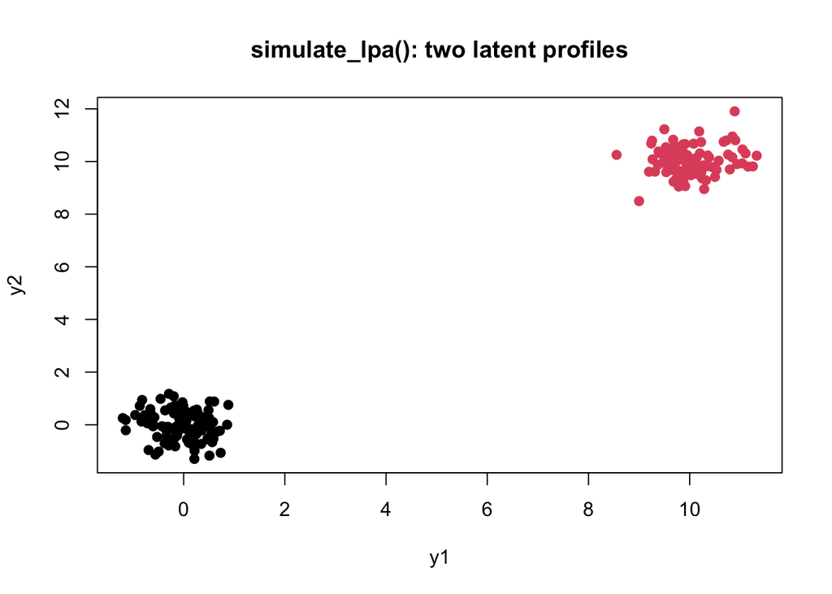

First two indicators coloured by true profile.

```r
lab <- r$data[[grep("class|profile|true", names(r$data), value = TRUE)[1]]]
plot(r$data[[1]], r$data[[2]], col = as.integer(factor(lab)), pch = 19,
     xlab = names(r$data)[1], ylab = names(r$data)[2],
     main = "simulate_lpa(): two latent profiles")
```

## `simulate_lca()`

Generate binary-indicator data with known latent class structure. All item response probabilities are specified explicitly.

**Signature**

```r
args(simulate_lca)
```

```
#> function (item_probs, class_probs, n, seed = NULL)
#> NULL
```

**Example**

```r
item_probs <- matrix(c(0.9, 0.1, 0.9, 0.1,
                       0.1, 0.9, 0.1, 0.9), nrow = 4, ncol = 2)
r <- simulate_lca(item_probs = item_probs, class_probs = c(0.5, 0.5),
                  n = 200, seed = 1)
head(r$data)
```

|  | item1 | item2 | item3 | item4 | true_class |
| --- | --- | --- | --- | --- | --- |
| 1 | 0 | 1 | 0 | 1 | 2 |
| 2 | 0 | 1 | 1 | 1 | 2 |
| 3 | 1 | 1 | 1 | 1 | 1 |
| 4 | 1 | 0 | 1 | 0 | 1 |
| 5 | 0 | 0 | 1 | 1 | 2 |
| 6 | 1 | 0 | 0 | 0 | 1 |

```r
str(r$params)
```

```
#> List of 2
#>  $ item_probs : num [1:4, 1:2] 0.9 0.1 0.9 0.1 0.1 0.9 0.1 0.9
#>  $ class_probs: num [1:2] 0.5 0.5
```

## `simulate_regression()`

Generate a linear-regression dataset with fully specified ground-truth coefficients and predictor standard deviations, designed so that `lm(y ~ ., data = r$data)` recovers the true coefficients at large `n`.

**Signature**

```r
args(simulate_regression)
```

```
#> function (coefs, predictor_sds, error_sd, n, seed = NULL)
#> NULL
```

**Example**

```r
coefs <- c("(Intercept)" = 2, x1 = 3, x2 = -1)
r <- simulate_regression(coefs = coefs,
                         predictor_sds = c(x1 = 1, x2 = 1),
                         error_sd = 0.5, n = 500, seed = 42)
head(r$data)
```

|  | y | x1 | x2 |
| --- | --- | --- | --- |
| 1 | 6.2462639 | 1.3709584 | 1.029140719 |
| 2 | -0.3468083 | -0.5646982 | 0.914774868 |
| 3 | 3.5772082 | 0.3631284 | -0.002456267 |
| 4 | 3.9510650 | 0.6328626 | 0.136009552 |
| 5 | 3.4349918 | 0.4042683 | -0.720153545 |
| 6 | 1.5810093 | -0.1061245 | -0.198124330 |

```r
coef(lm(y ~ ., data = r$data))   # should be close to c(2, 3, -1)
```

```
#> (Intercept)          x1          x2
#>   1.9798791   3.0200245  -0.9995026
```

```r
str(r$params)
```

```
#> List of 3
#>  $ coefs        : Named num [1:3] 2 3 -1
#>   ..- attr(*, "names")= chr [1:3] "(Intercept)" "x1" "x2"
#>  $ predictor_sds: Named num [1:2] 1 1
#>   ..- attr(*, "names")= chr [1:2] "x1" "x2"
#>  $ error_sd     : num 0.5
```

## `simulate_fa()`

Generate multivariate normal data from an explicit factor model. The implied covariance matrix $\Sigma = \Lambda \Phi \Lambda' + \Psi$ is fully specified and stored for direct comparison with estimated covariances.

**Signature**

```r
args(simulate_fa)
```

```
#> function (loadings, phi = NULL, psi = NULL, n, seed = NULL)
#> NULL
```

**Example**

```r
# Two orthogonal factors, 6 indicators (3 per factor)
loadings <- matrix(c(0.8, 0.7, 0.6, 0,   0,   0,
                     0,   0,   0,   0.8, 0.7, 0.6),
                   nrow = 6, ncol = 2)  # byrow = FALSE (default)
r <- simulate_fa(loadings = loadings, n = 500, seed = 1)
head(r$data)                  # y1..y6
```

|  | y1 | y2 | y3 | y4 | y5 | y6 |
| --- | --- | --- | --- | --- | --- | --- |
| 1 | -0.6264538 | -0.2867691 | 0.6872958 | 0.8500435 | -0.25814404 | -1.3029429 |
| 2 | 0.1836433 | -0.1431132 | 0.9880918 | -0.9253130 | -2.11074925 | -1.3767721 |
| 3 | -0.8356286 | -1.4482595 | -1.3642366 | 0.8935812 | 1.84231557 | 0.3183376 |
| 4 | 1.5952808 | 0.9027132 | 0.9486193 | -0.9410097 | -0.09675418 | 0.5246837 |
| 5 | 0.3295078 | 1.0060585 | 0.3986777 | 0.5389521 | 0.25554192 | -0.2640993 |
| 6 | -0.8204684 | 0.8611280 | -1.5296040 | -0.1819744 | 0.47507118 | 1.0349870 |

```r
r$params$sigma_implied        # implied covariance matrix
```

```
#>      [,1] [,2] [,3] [,4] [,5] [,6]
#> [1,] 1.00 0.56 0.48 0.00 0.00 0.00
#> [2,] 0.56 1.00 0.42 0.00 0.00 0.00
#> [3,] 0.48 0.42 1.00 0.00 0.00 0.00
#> [4,] 0.00 0.00 0.00 1.00 0.56 0.48
#> [5,] 0.00 0.00 0.00 0.56 1.00 0.42
#> [6,] 0.00 0.00 0.00 0.48 0.42 1.00
```

## `simulate_seq_clusters()`

Generate wide-format sequence data where each row is drawn from one of K Markov chains (clusters), each governed by its own transition matrix. Matrices can be supplied explicitly or generated at random.

**Signature**

```r
args(simulate_seq_clusters)
```

```
#> function (trans_list = NULL, props = NULL, n = 300L, seq_length = 20L,
#>     init_probs = NULL, n_clusters = 3L, n_states = 10L, states = NULL,
#>     seed = NULL)
#> NULL
```

**Example**

```r
m1 <- matrix(c(0.8, 0.2, 0.3, 0.7), nrow = 2, byrow = TRUE,
             dimnames = list(c("A","B"), c("A","B")))
m2 <- matrix(c(0.2, 0.8, 0.7, 0.3), nrow = 2, byrow = TRUE,
             dimnames = list(c("A","B"), c("A","B")))
r <- simulate_seq_clusters(trans_list = list(m1, m2), n = 100, seed = 1)
head(r$data)
```

|  | T1 | T2 | T3 | T4 | T5 | T6 | T7 | T8 | T9 | T10 | T11 | T12 | T13 | T14 | T15 | T16 | T17 | T18 | T19 | T20 | true_cluster |
| --- | --- | --- | --- | --- | --- | --- | --- | --- | --- | --- | --- | --- | --- | --- | --- | --- | --- | --- | --- | --- | --- |
| 1 | A | B | A | A | B | A | B | A | A | B | B | B | A | B | A | B | B | A | B | A | 2 |
| 2 | A | B | A | B | B | A | B | A | B | A | B | A | B | A | A | B | A | B | B | A | 2 |
| 3 | A | A | A | A | A | A | A | A | A | B | B | B | B | B | B | B | B | B | B | B | 1 |
| 4 | B | A | A | A | B | B | B | B | A | A | A | B | A | A | A | B | B | A | A | B | 1 |
| 5 | B | A | A | B | B | A | B | B | B | A | B | A | B | B | A | B | A | A | B | B | 2 |
| 6 | B | B | B | B | B | B | B | B | B | A | B | B | A | B | A | A | A | B | A | A | 1 |

```r
str(r$params)
```

```
#> List of 3
#>  $ trans_list:List of 2
#>   ..$ : num [1:2, 1:2] 0.8 0.3 0.2 0.7
#>   .. ..- attr(*, "dimnames")=List of 2
#>   .. .. ..$ : chr [1:2] "A" "B"
#>   .. .. ..$ : chr [1:2] "A" "B"
#>   ..$ : num [1:2, 1:2] 0.2 0.7 0.8 0.3
#>   .. ..- attr(*, "dimnames")=List of 2
#>   .. .. ..$ : chr [1:2] "A" "B"
#>   .. .. ..$ : chr [1:2] "A" "B"
#>  $ props     : num [1:2] 0.5 0.5
#>  $ init_probs:List of 2
#>   ..$ : Named num [1:2] 0.5 0.5
#>   .. ..- attr(*, "names")= chr [1:2] "A" "B"
#>   ..$ : Named num [1:2] 0.5 0.5
#>   .. ..- attr(*, "names")= chr [1:2] "A" "B"
```